# EDRM878 Homework 2

Tiejun Zhang

### 3.16.Children were asked to build towers out of cubical and cylindrical blocks as high as they could [20, 33], and the number of blocks used and the time taken were recorded. The data (data set: blocks) and a fuller description are given in Problem 2.18 (p. 88). In that problem, a linear regression model was fitted to model the time to build the towers, based on the initial examination in Problem 1.9 (p. 28).

```r
library(GLMsData)
data(blocks)
str(blocks)
```

```
'data.frame':   100 obs. of  6 variables:
 $ Child : Factor w/ 25 levels "A","B","C","D",..: 1 2 3 4 5 6 7 8 9 10 ...
 $ Number: int  11 9 8 9 10 13 10 7 6 12 ...
 $ Time  : num  30 19 18.6 23 29 178 42 20.2 12 39.2 ...
 $ Trial : int  1 1 1 1 1 1 1 1 1 1 ...
 $ Shape : Factor w/ 2 levels "Cube","Cylinder": 1 1 1 1 1 1 1 1 1 1 ...
 $ Age   : num  4.67 5 4.42 4.33 4.33 4.83 4.42 5 3.58 4 ...
```

```r
summary(blocks)
```

```
     Child        Number           Time            Trial          Shape         Age
 A      : 4   Min.   : 3.00   Min.   :  6.00   Min.   :1.0   Cube    :50   Min.   :2.420
 B      : 4   1st Qu.: 5.00   1st Qu.: 14.40   1st Qu.:1.0   Cylinder:50   1st Qu.:3.670
 C      : 4   Median : 6.00   Median : 20.20   Median :1.5                 Median :4.000
 D      : 4   Mean   : 6.82   Mean   : 29.59   Mean   :1.5                 Mean   :4.026
 E      : 4   3rd Qu.: 8.00   3rd Qu.: 35.00   3rd Qu.:2.0                 3rd Qu.:4.580
 F      : 4   Max.   :13.00   Max.   :178.00   Max.   :2.0                 Max.   :5.080
 (Other):76
```

#### 1.Perform a diagnostic analysis of the linear regression model fitted in Problem 2.18 (p. 88), and show a transformation of the response is necessary.

```r
# fit model
linear.model <-lm(Time~Shape, data = blocks)
summary(linear.model)
```

```
Call:
lm(formula = Time ~ Shape, data = blocks)

Residuals:
    Min      1Q  Median      3Q     Max
-29.416 -14.268  -6.816   7.032 141.184

Coefficients:
              Estimate Std. Error t value Pr(>|t|)
(Intercept)     36.816      3.496  10.531  < 2e-16 ***
ShapeCylinder  -14.448      4.944  -2.922  0.00431 **
---
Signif. codes:  0 ‘***’ 0.001 ‘**’ 0.01 ‘*’ 0.05 ‘.’ 0.1 ‘ ’ 1

Residual standard error: 24.72 on 98 degrees of freedom
Multiple R-squared:  0.08015,   Adjusted R-squared:  0.07077
F-statistic:  8.54 on 1 and 98 DF,  p-value: 0.004315
```

The model only has one explanatory variable “Shape”. It is a factor of two levels: Cube and Cylinder.

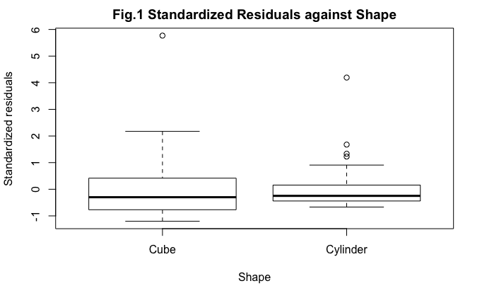

```r
# linearity check
plot(rstandard(linear.model) ~ blocks$Shape, ylab = "Standardized residuals", xlab = "Shape", main = "Fig.1 Standardized Residuals against Shape")
```

Fig1 suggests that the relationship between the residuals and Shape is not linear, for Shape is a two-level factor.

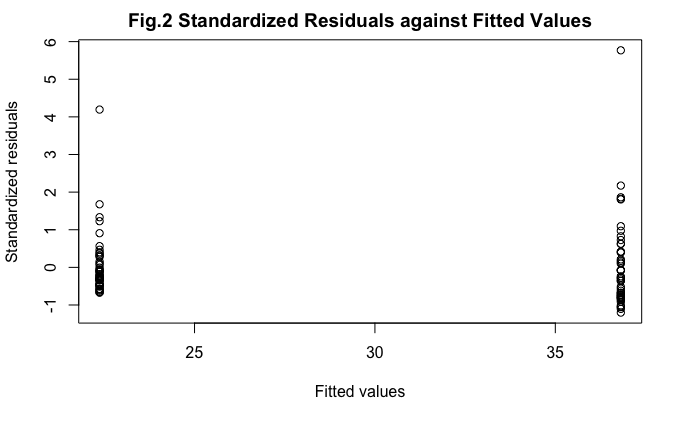

```r
# Constant variance check
plot(rstandard(linear.model) ~ fitted(linear.model), ylab = "Standardized residuals", xlab = "Fitted values", main = "Fig.2 Standardized Residuals against Fitted Values")
```

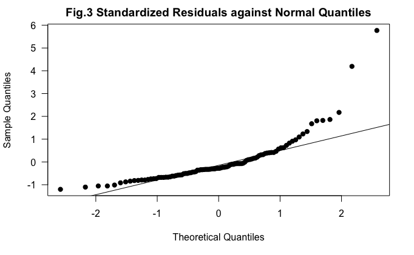

```r
# normality check
qqnorm(rstandard(linear.model), las = 1, pch = 19, main = "Fig.3 Standardized Residuals against Normal Quantiles")
qqline(rstandard(linear.model))
```

Fig3 indicates the residuals are not normally distributed. The distribution has a heavy up tail.

```r
# Influential Observations
inf_ms <- influence.measures(linear.model)

# Influential on three criteria
rowSums(inf_ms$is.inf)
```

```
  1   2   3   4   5   6   7   8   9  10  11  12  13  14  15  16  17  18  19  20  21  22
  0   0   0   0   0   3   0   0   0   0   0   0   0   0   0   0   0   0   0   0   0   0
 23  24  25  26  27  28  29  30  31  32  33  34  35  36  37  38  39  40  41  42  43  44
  0   0   0   0   0   0   0   0   0   0   0   0   0   0   0   0   0   0   0   0   0   0
 45  46  47  48  49  50  51  52  53  54  55  56  57  58  59  60  61  62  63  64  65  66
  0   0   0   0   0   0   0   0   0   0   0   0   0   0   0   0   0   0   0   0   0   0
 67  68  69  70  71  72  73  74  75  76  77  78  79  80  81  82  83  84  85  86  87  88
  0   0   0   0   0   0   0   0   0   2   0   0   0   0   0   0   0   0   0   0   0   0
 89  90  91  92  93  94  95  96  97  98  99 100
  0   0   0   0   0   0   0   0   0   0   0   0
```

```r
table(rowSums(inf_ms$is.inf))
```

```
 0  2  3
98  1  1
```

```r
# Influential observations
inf_ms$is.inf[c(6, 76),]
```

```
   dfb.1_ dfb.ShpC dffit cov.r cook.d   hat
6    TRUE    FALSE  TRUE  TRUE  FALSE FALSE
76  FALSE    FALSE  TRUE  TRUE  FALSE FALSE
```

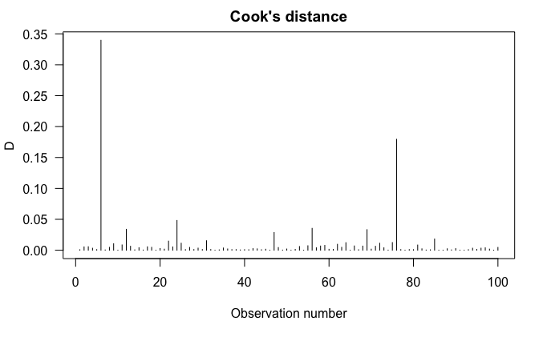

```r
# Plots
# Cook,s distance
plot(cooks.distance(linear.model), type = "h", main = "Cook's distance", ylab = "D", xlab = "Observation number", las = 1)
```

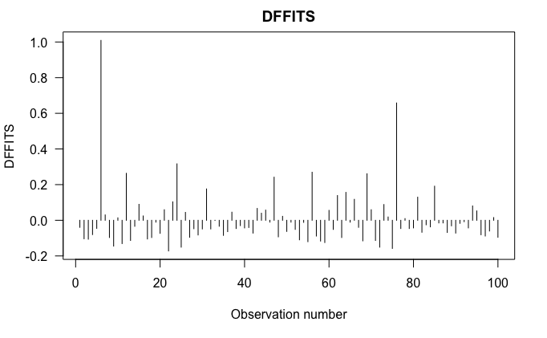

```r
# DFFITS
plot(dffits(linear.model), type = "h", main = "DFFITS", ylab = "DFFITS", xlab = "Observation number", las = 1)
```

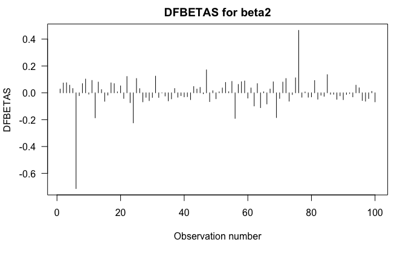

```r
# DFBETAS
plot(dfbetas(linear.model)[, 2], type = "h", main = "DFBETAS for beta2", ylab = "DFBETAS", xlab = "Observation number", las = 1)
```

98 observations are not declared influential on any of the criteria; Observation 6 is identified influnetial on all three criteria and observation 76 is declared influential on two criteria.

The residuals show non-normality, non-constant variance and two influential observations, therefore, it is necessary to transform the response variable.

#### 2.Fit an appropriate linear regression model to the data after applying the transformation, ensuring a diagnostic analysis.

```r
# fit model
m0 <- lm(log(Time) ~ 1, data = blocks)
m1 <- update(m0, . ~ . + Shape*Age)
anova(m1)
```

```
Analysis of Variance Table

Response: log(Time)
          Df Sum Sq Mean Sq F value   Pr(>F)
Shape      1  6.283  6.2828 14.8422 0.000211 ***
Age        1  0.000  0.0001  0.0002 0.989017
Shape:Age  1  0.307  0.3069  0.7250 0.396644
Residuals 96 40.638  0.4233
---
Signif. codes:  0 ‘***’ 0.001 ‘**’ 0.01 ‘*’ 0.05 ‘.’ 0.1 ‘ ’ 1
```

```r
t.model <- lm(log(Time) ~ Shape, data = blocks)
```

The sequential tests suggest that only Shape is an effective predictor (p < 0.05) for the log-tranformed response.

Diagnostic Analysis

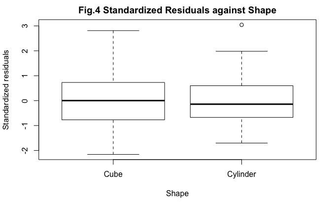

```r
plot(rstandard(t.model) ~ blocks$Shape, ylab = "Standardized residuals", xlab = "Shape", main = "Fig.4 Standardized Residuals against Shape")
```

Fig4 still shows a non-linear relationship but with less extreme points on up tail.

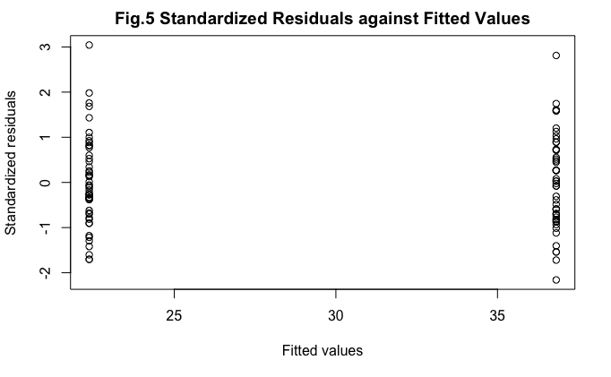

```r
# Constant variance check
plot(rstandard(t.model) ~ fitted(linear.model), ylab = "Standardized residuals", xlab = "Fitted values", main = "Fig.5 Standardized Residuals against Fitted Values")
```

Fig5 shows the variance appear to be constant between two shapes.

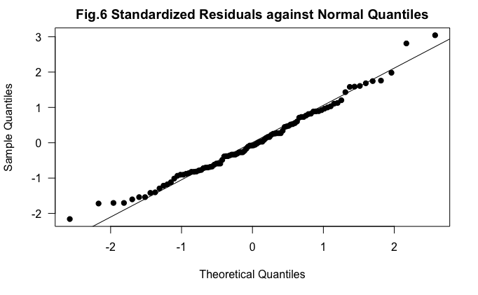

```r
# normality check
qqnorm(rstandard(t.model), las = 1, pch = 19, main = "Fig.6 Standardized Residuals against Normal Quantiles")
qqline(rstandard(t.model))
```

Fig6 indicates that the residuals are quite close to a normal distribution.

```r
# Influential Observations
trf_inf_ms <- influence.measures(t.model)

# Influential on three criteria
rowSums(trf_inf_ms$is.inf)
```

```
  1   2   3   4   5   6   7   8   9  10  11  12  13  14  15  16  17  18  19  20  21  22
  0   0   0   0   0   1   0   0   0   0   0   0   0   0   0   0   0   0   0   0   0   0
 23  24  25  26  27  28  29  30  31  32  33  34  35  36  37  38  39  40  41  42  43  44
  0   0   0   0   0   0   0   0   0   0   0   0   0   0   0   0   0   0   0   0   0   0
 45  46  47  48  49  50  51  52  53  54  55  56  57  58  59  60  61  62  63  64  65  66
  0   0   0   0   0   0   0   0   0   0   0   0   0   0   0   0   0   0   0   0   0   0
 67  68  69  70  71  72  73  74  75  76  77  78  79  80  81  82  83  84  85  86  87  88
  0   0   0   0   0   0   0   0   0   2   0   0   0   0   0   0   0   0   0   0   0   0
 89  90  91  92  93  94  95  96  97  98  99 100
  0   0   0   0   0   0   0   0   0   0   0   0
```

```r
table(rowSums(trf_inf_ms$is.inf))
```

```
 0  1  2
98  1  1
```

```r
# Influential observations
trf_inf_ms$is.inf[c(6, 76),]
```

```
   dfb.1_ dfb.ShpC dffit cov.r cook.d   hat
6   FALSE    FALSE FALSE  TRUE  FALSE FALSE
76  FALSE    FALSE  TRUE  TRUE  FALSE FALSE
```

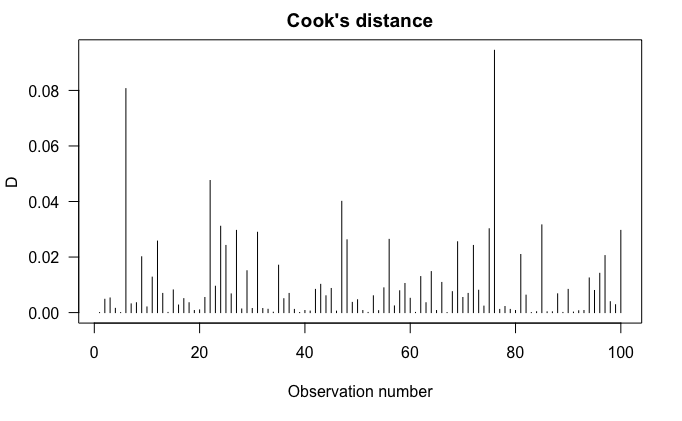

```r
# Plots
# Cook's distance
plot(cooks.distance(t.model), type = "h", main = "Cook's distance", ylab = "D", xlab = "Observation number", las = 1)
```

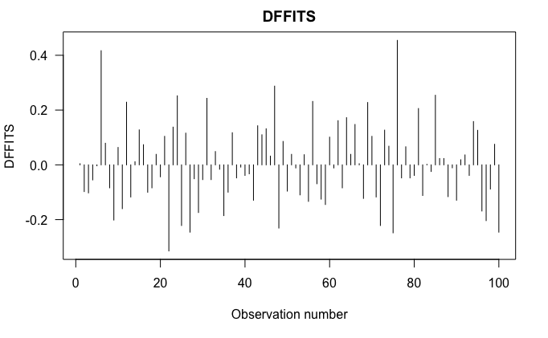

```r
# DFFITS
plot(dffits(t.model), type = "h", main = "DFFITS", ylab = "DFFITS", xlab = "Observation number", las = 1)
```

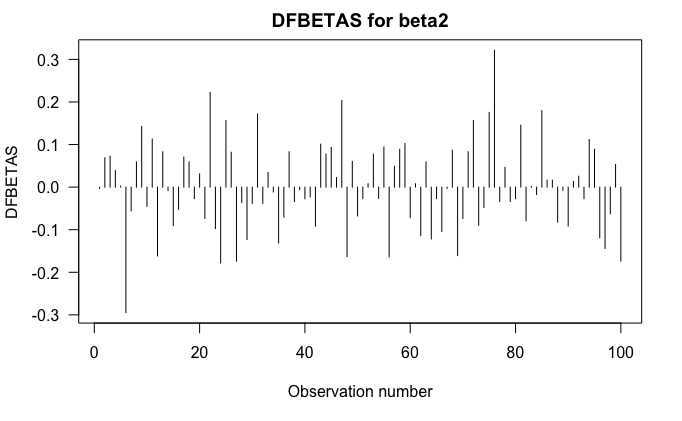

```r
# DFBETAS
plot(dfbetas(t.model)[, 2], type = "h", main = "DFBETAS for beta2", ylab = "DFBETAS", xlab = "Observation number", las = 1)
```

Overall, the model fit improved after a log-tranform of the response.